# Capstone Project: Bellabeat Marketing Strategy Analysis

Ryan Tang

2024-05-31

## Executive Summary

**Case Study:** Bellabeat Smart Device Usage Analysis

**Scenario:** As a junior data analyst for Bellabeat, a high-tech manufacturer of health-focused products for women, I have been tasked with analyzing smart device fitness data. The goal is to unlock new growth opportunities by understanding consumer usage patterns of non-Bellabeat smart devices. These insights will inform high-level marketing strategies presented to the executive team, including Urška Sršen (Co-founder and CCO).

### Phase 1: Ask

**Business Task:** Analyze smart device usage data from non-Bellabeat products (Fitbit) to identify consumer trends. These insights will be used to guide Bellabeat’s marketing strategy, aiming to position the company as a major contender in the global smart device market.

**Primary Objectives:** 1. Identify trends in smart device usage. 2. Determine how these trends apply to Bellabeat’s target clientele. 3. Formulate data-driven marketing strategies to enhance consumer engagement and growth.

**Key Stakeholders:**

- Urška Sršen (Co-founder and CCO)
- Sando Mur (Co-founder and Executive Team)
- Bellabeat Marketing Analytics Team

### Phase 2: Prepare

**Data Source:** The analysis utilizes the [FitBit Fitness Tracker Data](https://www.kaggle.com/datasets/arashnic/fitbit) (CC0: Public Domain), retrieved from Kaggle. This dataset comprises personal fitness tracker logs from thirty Fitbit users who consented to the submission of their personal tracker data.

**Data Structure:** The dataset spans two periods (12/03/2016 – 12/05/2016) and includes 11 CSV files detailing metrics such as heart rate, steps, and caloric expenditure. The data is structured in a long format.

**Data Credibility & Integrity Analysis (ROCCC):**

- Reliability: Low. The sample size (n=30) is small, limiting the ability to generalize findings to a broader population.
- Originality: Low. Data was collected via a third party (Amazon Mechanical Turk), necessitating scrutiny regarding data provenance.
- Comprehensive: Moderate. While the dataset offers diverse metrics (steps, calories, activity intensity), it lacks demographic context (age, gender, location).
- Current: Low. The data originates from 2016; user behaviors and wearable technology have likely evolved since then.
- Cited: Low. As third-party data, the original collection methodology is not fully transparent.

### Phase 3: Process

The `dailyActivity_merged.csv` file was selected for the primary analysis regarding daily usage patterns.

#### 3.1 Environment Setup

Loading necessary packages for data manipulation, cleaning, and analysis. #### Load libraries

```r
library(tidyverse)
library(skimr)
library(janitor)
```

#### Data Import

```r
dailyact <- read.csv("dailyActivity_merged.csv")
```

#### Data Inspection

Previewing the dataset structure and content.

```r
head(dailyact)
```

```
##           Id ActivityDate TotalSteps TotalDistance TrackerDistance
## 1 1503960366    3/25/2016      11004          7.11            7.11
## 2 1503960366    3/26/2016      17609         11.55           11.55
## 3 1503960366    3/27/2016      12736          8.53            8.53
## 4 1503960366    3/28/2016      13231          8.93            8.93
## 5 1503960366    3/29/2016      12041          7.85            7.85
## 6 1503960366    3/30/2016      10970          7.16            7.16
##   LoggedActivitiesDistance VeryActiveDistance ModeratelyActiveDistance
## 1                        0               2.57                     0.46
## 2                        0               6.92                     0.73
## 3                        0               4.66                     0.16
## 4                        0               3.19                     0.79
## 5                        0               2.16                     1.09
## 6                        0               2.36                     0.51
##   LightActiveDistance SedentaryActiveDistance VeryActiveMinutes
## 1                4.07                       0                33
## 2                3.91                       0                89
## 3                3.71                       0                56
## 4                4.95                       0                39
## 5                4.61                       0                28
## 6                4.29                       0                30
##   FairlyActiveMinutes LightlyActiveMinutes SedentaryMinutes Calories
## 1                  12                  205              804     1819
## 2                  17                  274              588     2154
## 3                   5                  268              605     1944
## 4                  20                  224             1080     1932
## 5                  28                  243              763     1886
## 6                  13                  223             1174     1820
```

#### Data Summaries

Generating an overview of column distributions and missing values.

```r
skim_without_charts(dailyact)
```

Data summary

| Name | dailyact |
| --- | --- |
| Number of rows | 457 |
| Number of columns | 15 |
| _______________________ |  |
| Column type frequency: |  |
| character | 1 |
| numeric | 14 |
| ________________________ |  |
| Group variables | None |

**Variable type: character**

| skim_variable | n_missing | complete_rate | min | max | empty | n_unique | whitespace |
| --- | --- | --- | --- | --- | --- | --- | --- |
| ActivityDate | 0 | 1 | 8 | 9 | 0 | 32 | 0 |

**Variable type: numeric**

| skim_variable | n_missing | complete_rate | mean | sd | p0 | p25 | p50 | p75 | p100 |
| --- | --- | --- | --- | --- | --- | --- | --- | --- | --- |
| Id | 0 | 1 | 4.628595e+09 | 2.293781e+09 | 1503960366 | 2.347168e+09 | 4.057193e+09 | 6.391747e+09 | 8.877689e+09 |
| TotalSteps | 0 | 1 | 6.546560e+03 | 5.398490e+03 | 0 | 1.988000e+03 | 5.986000e+03 | 1.019800e+04 | 2.849700e+04 |
| TotalDistance | 0 | 1 | 4.660000e+00 | 4.080000e+00 | 0 | 1.410000e+00 | 4.090000e+00 | 7.160000e+00 | 2.753000e+01 |
| TrackerDistance | 0 | 1 | 4.610000e+00 | 4.070000e+00 | 0 | 1.280000e+00 | 4.090000e+00 | 7.110000e+00 | 2.753000e+01 |
| LoggedActivitiesDistance | 0 | 1 | 1.800000e-01 | 8.500000e-01 | 0 | 0.000000e+00 | 0.000000e+00 | 0.000000e+00 | 6.730000e+00 |
| VeryActiveDistance | 0 | 1 | 1.180000e+00 | 2.490000e+00 | 0 | 0.000000e+00 | 0.000000e+00 | 1.310000e+00 | 2.192000e+01 |
| ModeratelyActiveDistance | 0 | 1 | 4.800000e-01 | 8.300000e-01 | 0 | 0.000000e+00 | 2.000000e-02 | 6.700000e-01 | 6.400000e+00 |
| LightActiveDistance | 0 | 1 | 2.890000e+00 | 2.240000e+00 | 0 | 8.700000e-01 | 2.930000e+00 | 4.460000e+00 | 1.251000e+01 |
| SedentaryActiveDistance | 0 | 1 | 0.000000e+00 | 1.000000e-02 | 0 | 0.000000e+00 | 0.000000e+00 | 0.000000e+00 | 1.000000e-01 |
| VeryActiveMinutes | 0 | 1 | 1.662000e+01 | 2.892000e+01 | 0 | 0.000000e+00 | 0.000000e+00 | 2.500000e+01 | 2.020000e+02 |
| FairlyActiveMinutes | 0 | 1 | 1.307000e+01 | 3.621000e+01 | 0 | 0.000000e+00 | 1.000000e+00 | 1.600000e+01 | 6.600000e+02 |
| LightlyActiveMinutes | 0 | 1 | 1.700700e+02 | 1.222100e+02 | 0 | 6.400000e+01 | 1.810000e+02 | 2.570000e+02 | 7.200000e+02 |
| SedentaryMinutes | 0 | 1 | 9.952800e+02 | 3.370200e+02 | 32 | 7.280000e+02 | 1.057000e+03 | 1.285000e+03 | 1.440000e+03 |
| Calories | 0 | 1 | 2.189450e+03 | 8.154800e+02 | 0 | 1.776000e+03 | 2.062000e+03 | 2.667000e+03 | 4.562000e+03 |

#### Column Validation

```r
colnames(dailyact)
```

```
##  [1] "Id"                       "ActivityDate"
##  [3] "TotalSteps"               "TotalDistance"
##  [5] "TrackerDistance"          "LoggedActivitiesDistance"
##  [7] "VeryActiveDistance"       "ModeratelyActiveDistance"
##  [9] "LightActiveDistance"      "SedentaryActiveDistance"
## [11] "VeryActiveMinutes"        "FairlyActiveMinutes"
## [13] "LightlyActiveMinutes"     "SedentaryMinutes"
## [15] "Calories"
```

**Observation**: Initial inspection reveals no null values. However, a review of schema definitions is required to ensure data types align with analysis needs.

#### Schema Verification

```r
glimpse(dailyact)
```

```
## Rows: 457
## Columns: 15
## $ Id                       <dbl> 1503960366, 1503960366, 1503960366, 150396036…
## $ ActivityDate             <chr> "3/25/2016", "3/26/2016", "3/27/2016", "3/28/…
## $ TotalSteps               <int> 11004, 17609, 12736, 13231, 12041, 10970, 122…
## $ TotalDistance            <dbl> 7.11, 11.55, 8.53, 8.93, 7.85, 7.16, 7.86, 7.…
## $ TrackerDistance          <dbl> 7.11, 11.55, 8.53, 8.93, 7.85, 7.16, 7.86, 7.…
## $ LoggedActivitiesDistance <dbl> 0, 0, 0, 0, 0, 0, 0, 0, 0, 0, 0, 0, 0, 0, 0, …
## $ VeryActiveDistance       <dbl> 2.57, 6.92, 4.66, 3.19, 2.16, 2.36, 2.29, 3.3…
## $ ModeratelyActiveDistance <dbl> 0.46, 0.73, 0.16, 0.79, 1.09, 0.51, 0.49, 0.8…
## $ LightActiveDistance      <dbl> 4.07, 3.91, 3.71, 4.95, 4.61, 4.29, 5.04, 3.6…
## $ SedentaryActiveDistance  <dbl> 0.00, 0.00, 0.00, 0.00, 0.00, 0.00, 0.00, 0.0…
## $ VeryActiveMinutes        <int> 33, 89, 56, 39, 28, 30, 33, 47, 40, 15, 43, 3…
## $ FairlyActiveMinutes      <int> 12, 17, 5, 20, 28, 13, 12, 21, 11, 30, 18, 18…
## $ LightlyActiveMinutes     <int> 205, 274, 268, 224, 243, 223, 239, 200, 244, …
## $ SedentaryMinutes         <int> 804, 588, 605, 1080, 763, 1174, 820, 866, 636…
## $ Calories                 <int> 1819, 2154, 1944, 1932, 1886, 1820, 1889, 186…
```

**Correction Required**: The `ActivityDate` column is currently stored as a character string. For temporal analysis, this must be converted to a Date object.

#### Data Type Conversion

```r
dailyact$ActivityDate <- as.Date(dailyact$ActivityDate, "%m/%d/%Y")
```

That looks better. To be able to gain more insights from this data, we can extract even more information from the date data type.

#### Feature Engineering

To facilitate granular analysis, we will extract specific temporal attributes (Month, Day, Day of Week).

```r
dailyact <- dailyact %>%
  mutate(Month = format(ActivityDate, "%m")) %>%
  mutate(Day = format(ActivityDate, "%d")) %>%
  mutate(Day_of_week = wday(ActivityDate, label=TRUE))
```

#### Standardization

Standardizing column names to snake_case for consistency and readability.

```r
dailyact <- dailyact %>%
  clean_names()
```

### Phase 4: Analyze

With the data cleaned and formatted, we proceed to exploratory data analysis (EDA) to uncover distribution patterns and outliers.

#### Unique Identifier Check

```r
n_distinct(dailyact$id)
```

```
## [1] 35
```

**Note**: There are 35 distinct user IDs, which contradicts the initial dataset description of 30 users. This discrepancy suggests additional data points were merged or metadata was inaccurate.

#### Summary Statistics

```r
dailyact %>%
  select(total_steps, total_distance,very_active_distance,
         moderately_active_distance, light_active_distance,
         sedentary_active_distance, very_active_minutes,
         fairly_active_minutes, lightly_active_minutes,
         sedentary_minutes, calories) %>%
  summary()
```

```
##   total_steps    total_distance   very_active_distance
##  Min.   :    0   Min.   : 0.000   Min.   : 0.000
##  1st Qu.: 1988   1st Qu.: 1.410   1st Qu.: 0.000
##  Median : 5986   Median : 4.090   Median : 0.000
##  Mean   : 6547   Mean   : 4.664   Mean   : 1.181
##  3rd Qu.:10198   3rd Qu.: 7.160   3rd Qu.: 1.310
##  Max.   :28497   Max.   :27.530   Max.   :21.920
##  moderately_active_distance light_active_distance sedentary_active_distance
##  Min.   :0.0000             Min.   : 0.00         Min.   :0.000000
##  1st Qu.:0.0000             1st Qu.: 0.87         1st Qu.:0.000000
##  Median :0.0200             Median : 2.93         Median :0.000000
##  Mean   :0.4786             Mean   : 2.89         Mean   :0.001904
##  3rd Qu.:0.6700             3rd Qu.: 4.46         3rd Qu.:0.000000
##  Max.   :6.4000             Max.   :12.51         Max.   :0.100000
##  very_active_minutes fairly_active_minutes lightly_active_minutes
##  Min.   :  0.00      Min.   :  0.00        Min.   :  0.0
##  1st Qu.:  0.00      1st Qu.:  0.00        1st Qu.: 64.0
##  Median :  0.00      Median :  1.00        Median :181.0
##  Mean   : 16.62      Mean   : 13.07        Mean   :170.1
##  3rd Qu.: 25.00      3rd Qu.: 16.00        3rd Qu.:257.0
##  Max.   :202.00      Max.   :660.00        Max.   :720.0
##  sedentary_minutes    calories
##  Min.   :  32.0    Min.   :   0
##  1st Qu.: 728.0    1st Qu.:1776
##  Median :1057.0    Median :2062
##  Mean   : 995.3    Mean   :2189
##  3rd Qu.:1285.0    3rd Qu.:2667
##  Max.   :1440.0    Max.   :4562
```

**Interpretation**: * Activity Levels: The average daily step count is 6,547, with an average caloric burn of 2,189. * Sedentary Behavior: Users spend a significant portion of their day in sedentary states (avg. 995 minutes/approx. 16.5 hours), significantly outweighing active minutes.

#### Aggregation by Day of Week

Analyzing weekly performance trends.

```r
dailyact %>%
  group_by(day_of_week) %>%
  summarise(average_steps = mean(total_steps),
            average_calories = mean(calories))
```

```
## # A tibble: 7 × 3
##   day_of_week average_steps average_calories
##   <ord>               <dbl>            <dbl>
## 1 Sun                 6058.            2168.
## 2 Mon                 7119.            2253.
## 3 Tue                 4915.            1742.
## 4 Wed                 7511.            2377.
## 5 Thu                 6847.            2298.
## 6 Fri                 6738.            2314.
## 7 Sat                 7090.            2278.
```

#### Activity Intensity by Day of Week

```r
dailyact %>%
  group_by(day_of_week) %>%
  summarise(average_active = mean(very_active_minutes),
            average_fairly_active = mean(fairly_active_minutes),
            average_lightly_active = mean(lightly_active_minutes),
            average_sedentary = mean(sedentary_minutes))
```

```
## # A tibble: 7 × 5
##   day_of_week average_active average_fairly_active average_lightly_active
##   <ord>                <dbl>                 <dbl>                  <dbl>
## 1 Sun                   15.3                  9.21                   164.
## 2 Mon                   19.0                 10.4                    172.
## 3 Tue                   13.2                  8.84                   135.
## 4 Wed                   17.0                 14.5                    190.
## 5 Thu                   17.4                 14.5                    167.
## 6 Fri                   16                   22.2                    178.
## 7 Sat                   19.0                 12.6                    190.
## # ℹ 1 more variable: average_sedentary <dbl>
```

### Phase 5: Share

This section visualizes the relationships between activity metrics to derive actionable insights.

#### Correlation: Steps vs. Calories

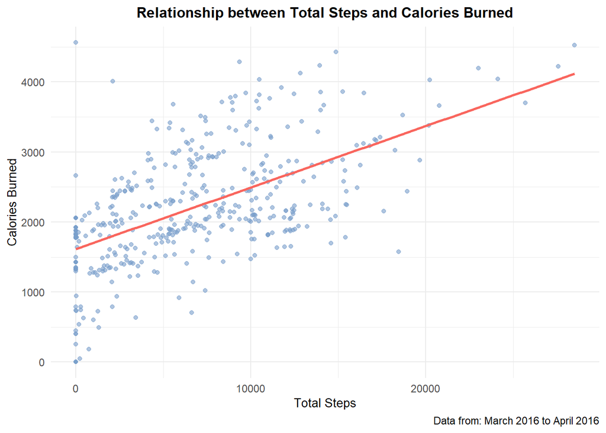

```r
ggplot(dailyact, mapping=aes(x = total_steps, y = calories)) +
  geom_point(color = '#799FCB', alpha = 0.6) +
  geom_smooth(method = 'lm', color = '#F9665E', se = FALSE) +
  labs(title = 'Relationship between Total Steps and Calories Burned',
       caption = 'Data from: March 2016 to April 2016',
       x = 'Total Steps',
       y = 'Calories Burned') +
  theme_minimal() +
  theme(
    plot.title = element_text(hjust = 0.5, size = 12, face = 'bold'),
    axis.title = element_text(size = 10),
    axis.text = element_text(size = 9)
  )
```

**Insight**: As expected, a strong positive correlation exists between total steps and calories burned. This establishes a baseline validity for the dataset and emphasizes the value of step-tracking features for weight management goals.

#### Distribution of Activity Types

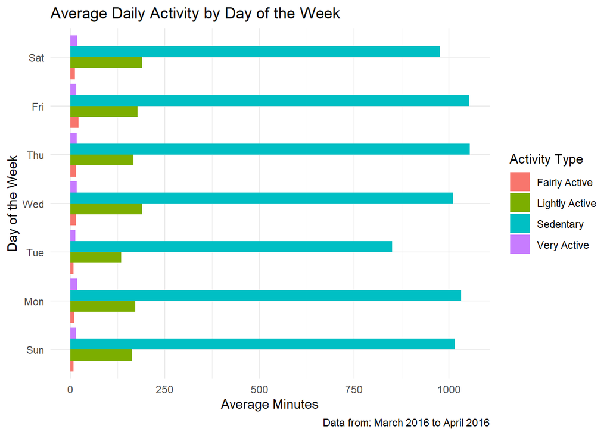

```r
#Get summary data
summary_data <- dailyact %>%
  group_by(day_of_week) %>%
  summarise(average_active = mean(very_active_minutes, na.rm = TRUE),
    average_fairly_active = mean(fairly_active_minutes, na.rm = TRUE),
    average_lightly_active = mean(lightly_active_minutes, na.rm =
    TRUE), average_sedentary = mean(sedentary_minutes, na.rm = TRUE))

#Reshape into long format
long_data <- summary_data %>%
  pivot_longer(cols = starts_with("average_"), names_to = "activity_type", values_to = "average_minutes")

#Rename for better readability
long_data$activity_type <- recode(long_data$activity_type, "average_active" = "Very Active", "average_fairly_active" = "Fairly Active", "average_lightly_active" = "Lightly Active", "average_sedentary" = "Sedentary")

#Plot graph
ggplot(long_data, aes(x = day_of_week, y = average_minutes, fill = activity_type)) +
  geom_bar(stat = "identity", position = position_dodge()) +
  coord_flip() +
  labs(title = 'Average Daily Activity by Day of the Week', caption = 'Data from: March 2016 to April 2016', x = 'Day of the Week', y = 'Average Minutes', fill = 'Activity Type') +
  theme_minimal()
```

**Insight**: The user base is predominantly sedentary or lightly active. “Fairly active” and “Very active” intervals constitute a marginal fraction of the day. This suggests a market opportunity to target users who are struggling to break sedentary habits.

#### Sedentary Behavior vs. Total Steps

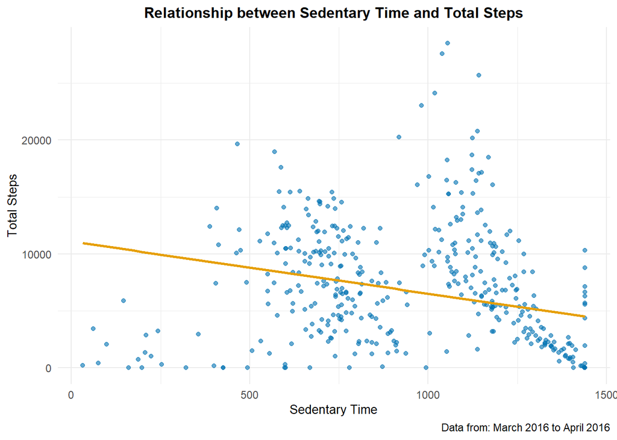

```r
ggplot(dailyact, mapping=aes(x = sedentary_minutes, y = total_steps)) +
  geom_point(color = '#0072B2', alpha = 0.6) +
  geom_smooth(method = 'lm', color = '#E69F00', se = FALSE) +
  labs(title = 'Relationship between Sedentary Time and Total Steps', caption = 'Data from: March 2016 to April 2016', x = 'Sedentary Time', y = 'Total Steps') +
  theme_minimal() +
  theme(
    plot.title = element_text(hjust = 0.5, size = 12, face = 'bold'),
    axis.title = element_text(size = 10),
    axis.text = element_text(size = 9)
  )
```

**Insight**: A negative correlation is observed: higher sedentary time is associated with lower daily step counts.

#### Light Activity vs. Total Steps

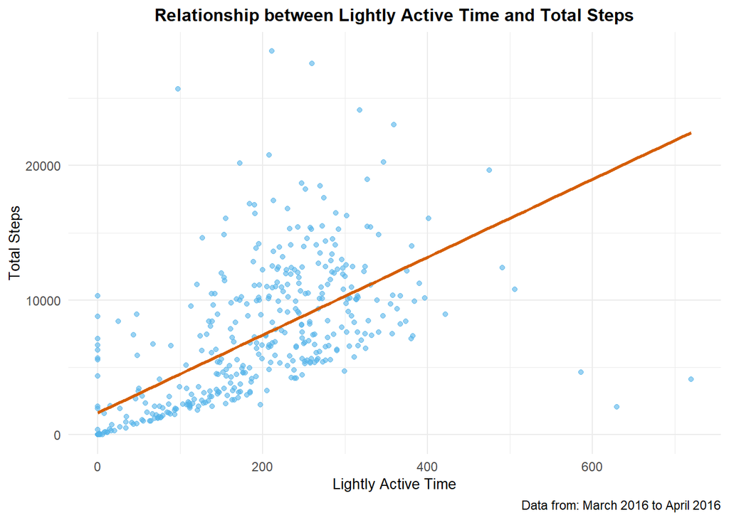

```r
ggplot(dailyact, mapping=aes(x = lightly_active_minutes, y = total_steps)) +
  geom_point(color = '#56B4E9', alpha = 0.6) +
  geom_smooth(method = 'lm', color = '#D55E00', se = FALSE) +
  labs(title = 'Relationship between Lightly Active Time and Total Steps', caption = 'Data from: March 2016 to April 2016', x = 'Lightly Active Time', y = 'Total Steps') +
  theme_minimal() +
  theme(
    plot.title = element_text(hjust = 0.5, size = 12, face = 'bold'),
    axis.title = element_text(size = 10),
    axis.text = element_text(size = 9)
  )
```

**Insight**: A strong positive correlation exists here. This indicates that “light activity” (e.g., walking, doing chores) is a primary driver of total daily steps for this demographic, rather than high-intensity workouts.

## Phase 6: Act

Based on the analysis of user trends, the following strategies are recommended to enhance Bellabeat’s marketing approach:

1. “Step Up for Health” Campaign:
- Rationale: The data confirms a direct link between steps and caloric burn.
- Action: Launch a campaign gamifying daily step counts. Use in-app challenges and push notifications to encourage users to beat their previous day’s record, emphasizing the caloric benefits.
2. Focus on Low-Barrier Entry (Light Activity):
- Rationale: Users are most responsive to “light activity” as a driver of steps, rather than intense exercise.
- Action: Develop content that promotes “hidden exercise”—taking the stairs, walking during calls, or short breaks. Position Bellabeat products not just for athletes, but for the everyday woman looking to reduce sedentary time.
3. Sedentary Lifestyle Education:
- Rationale: The high volume of sedentary minutes presents a health risk and a user pain point.
- Action: Implement “Inactivity Alerts” in the Bellabeat app (e.g., “You’ve been sitting for 60 minutes, time to stretch”). Back this up with educational blog posts and infographics detailing the health risks of prolonged sitting and the benefits of micro-movements.